# Problems and Windowing

# Problem specifications: running ConScape at scale

```
TaskLocalRNG()
```

# Data import

```
(func_hab = FunctionalHabitat(), betm = MovementFlow(QualityAndProximityWeighted()))
```

Define a function to benchmark allocations during initialisation:

```
benchmark_init_allocs (generic function with 1 method)
```

And run it for a range of sizes.

```
5-element Vector{Int64}:
     168440
    1584808
   17726800
  159909176
 1764234888
```

Now we can plot how much memory was allocated to run initialisation, and how much memory is used by the final `GridInit` object. Somewhere between these values is the maximum simlutaneous memory requirement, although the upper value is safer to use.

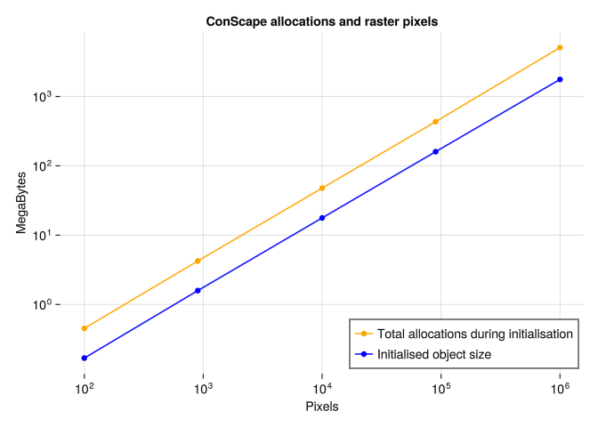

Importantly we see close to a linear relationship, with 5 kilobytes allocated per filled raster pixel, and 1.6 kilobyte of final object size.

```
5-element Vector{Float64}:
 4522.64
 4708.4
 4771.1888
 4821.290755555556
 5086.31328
```

## Allocations with missing data

With missing data in the Raster, allocations will in general be significantly less than if all pixels have qualities and affinities. However, there are a few caveats to this statement.

ConScape operates on strongly connected subgraphs, and if parts of the raster are not at all connected, they are split into separate `GridInit` objects. Overall this improves performance, but with very many tiny subgraphs there will be some memory overhead from initialisation.

Here we benchmark initialisation for a range of sparsities, with non-natural distribution of missing data.

```
10-element Vector{Int64}:
    1
    1
    1
    4
   13
  148
  876
 2768
 3456
 1878
```

We can see that final allocated size decrease with the sparsity of the data, but intermediate allocations spike as the number of disconnected subgraphs increases. It is unlikely that real data will have anywhere near this many subgraphs, as missing data is not evenly distributed, but patchy.

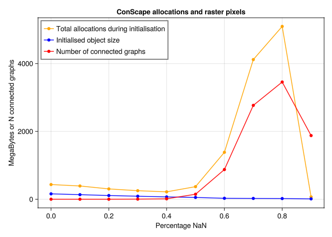